# Predicting Excessive Enforcement Patterns in Police Behavior After Vehicles Stops in New York

### Day, Dow and Weekday

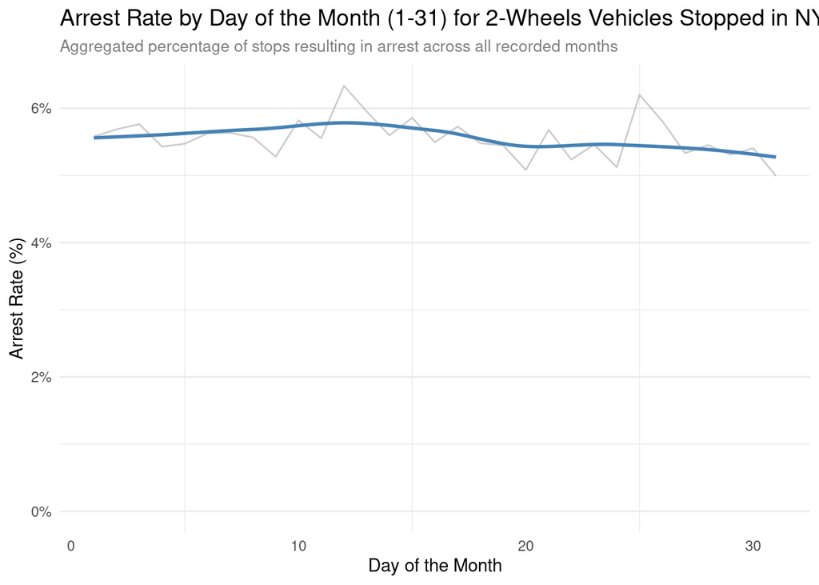

```r
daily_arrest_rate <- vehstops %>%
  filter(!is.na(day), !is.na(arrested)) %>%
  group_by(day) %>%
  summarise(
    total_stops = n(),
    arrests = sum(arrested == 1),
    rate = arrests / total_stops,
    .groups = "drop"
  )

daily_arrest_rate %>%
  ggplot(aes(x = day, y = rate)) +
  geom_line(color = "grey60", alpha = 0.5) +
  geom_smooth(method = "loess", color = "steelblue", se = FALSE) +
  scale_y_continuous(labels = scales::percent, limits = c(0, NA)) +
  theme_minimal() +
  theme(
    panel.grid.major.x = element_blank(),
    plot.title = element_text(size = 14),
    plot.subtitle = element_text(color = "grey50", size = 10)
  ) +
  labs(
    title = "Arrest Rate by Day of the Month (1-31) for 2-Wheels Vehicles Stopped in NYC",
    subtitle = "Aggregated percentage of stops resulting in arrest across all recorded months",
    x = "Day of the Month",
    y = "Arrest Rate (%)"
  )
```

What can we say?

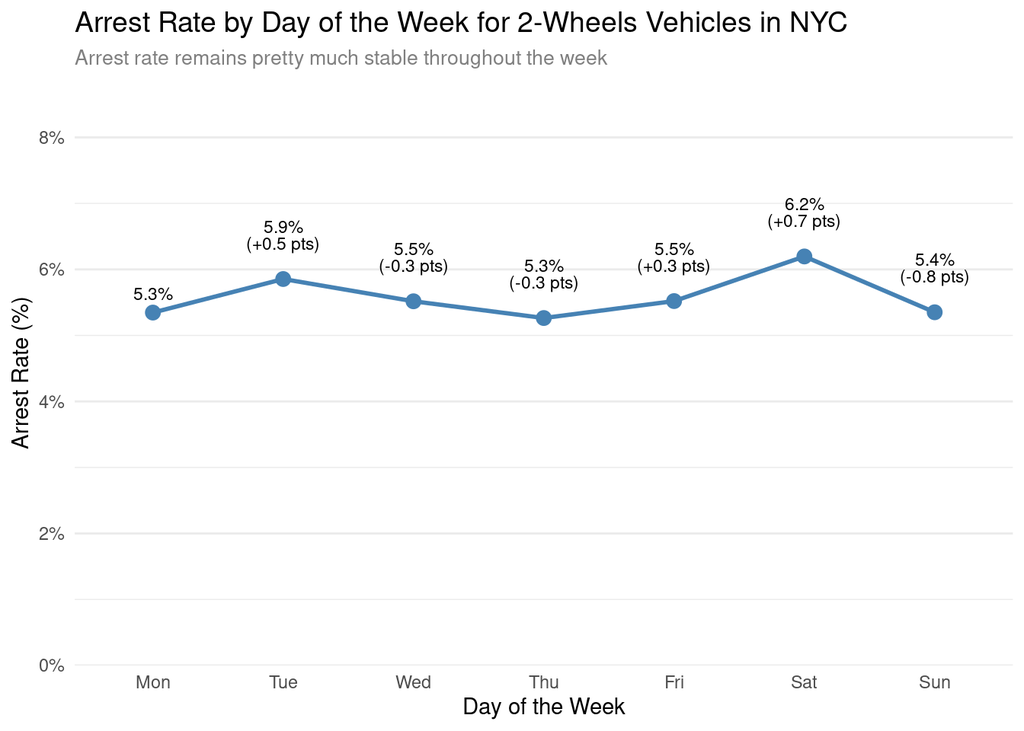

```r
daily_arrest_rate <- vehstops %>%
  filter(!is.na(dow), !is.na(arrested)) %>%
  group_by(dow) %>%
  summarise(
    total_stops = n(),
    arrests = sum(arrested == 1),
    rate = arrests / total_stops,
    .groups = "drop"
  ) %>%
  mutate(
    dow_label = factor(dow, levels = 1:7,
                       labels = c("Mon", "Tue", "Wed", "Thu", "Fri", "Sat", "Sun")),
    prev_rate = lag(rate),
    delta = (rate - prev_rate) * 100,
    label_text = ifelse(
      is.na(prev_rate),
      scales::percent(rate, accuracy = 0.1),
      paste0(scales::percent(rate, accuracy = 0.1),
             "\n(", ifelse(delta > 0, "+", ""), round(delta, 1), " pts)")
    )
  )

daily_arrest_rate %>%
  ggplot(aes(x = dow_label, y = rate, group = 1)) +
  geom_line(color = "steelblue", linewidth = 1) +
  geom_point(color = "steelblue", size = 3) +
  geom_text(aes(label = label_text), vjust = -1.0, size = 3, lineheight = 0.8) +
  scale_y_continuous(
    labels = scales::percent,
    limits = c(0, max(daily_arrest_rate$rate) * 1.3),
    expand = expansion(mult = c(0, 0.1))
  ) +
  theme_minimal() +
  theme(
    panel.grid.major.x = element_blank(),
    plot.title = element_text(size = 14),
    plot.subtitle = element_text(color = "grey50", size = 10)
  ) +
  labs(
    title = "Arrest Rate by Day of the Week for 2-Wheels Vehicles in NYC",
    subtitle = "Arrest rate remains pretty much stable throughout the week",
    x = "Day of the Week",
    y = "Arrest Rate (%)"
  )
```

What can we say?

- **Key finding**: The probability of an arrest given a stop peaks first on Tuesday at $5.9\%$ before dipping during mid-week, and then reaches its absolute maximum on Saturday at $6.2\%$, while the lowest arrest probabilities occur on Monday and Thursday at $5.3\%$.
- **Interpretation**: The overall variation across the week is relatively tight which suggests it is a less powerful predictor with respect to the other time-related ones.
- **Comment**: Surprisingly, the arrest rate peaks on Saturday ($6.2\%$) while mid-week has the highest stop count (see Univariate) but lower per-stop arrest probability.
- **Proposed Action**: We should treat the day of the week as a categorical dummy in order to use it in our models.

### Hour and Time Bracket

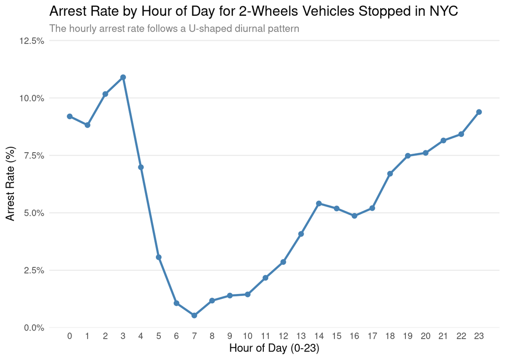

```r
hourly_arrest_rate <- vehstops %>%
  filter(!is.na(hour), !is.na(arrested)) %>%
  group_by(hour) %>%
  summarise(
    total_stops = n(),
    arrests = sum(arrested == 1),
    rate = arrests / total_stops,
    .groups = "drop"
  )

hourly_arrest_rate %>%
  ggplot(aes(x = hour, y = rate)) +
  geom_line(color = "steelblue", linewidth = 1) +
  geom_point(color = "steelblue", size = 2) +
  scale_x_continuous(breaks = 0:23) +
  scale_y_continuous(labels = scales::percent, limits = c(0, NA),
                     expand = expansion(mult = c(0, 0.15))) +
  theme_minimal() +
  theme(
    panel.grid.major.x = element_blank(),
    panel.grid.minor = element_blank(),
    plot.title = element_text(size = 14),
    plot.subtitle = element_text(color = "grey50", size = 10)
  ) +
  labs(
    title = "Arrest Rate by Hour of Day for 2-Wheels Vehicles Stopped in NYC",
    subtitle = "The hourly arrest rate follows a U-shaped diurnal pattern",
    x = "Hour of Day (0-23)",
    y = "Arrest Rate (%)"
  )
```

What can we say?

- **Key finding**: The line plot underlines the time-dependent pattern in the arrest rate resulting from stops across a 24-hour cycle. We observe a global minimum at 7:00 (07:00 AM), followed by a steady climb to a minor afternoon peak around 14:00 (02:00 PM). The absolute maximum occurs during the late-night and early-morning hours, specifically peaking at 3:00 (03:00 AM) with an arrest rate of nearly $11\%$.
- **Interpretation**: This fluctuation suggests that our exploratory data analysis is heavily influenced by variations in motorist behavior, law enforcement patterns, or both depending on the hour of the day.
- **Comment**: The low arrest rates during the morning commute hours (from 6:00 to 10:00) suggest that law enforcement actions during this window might focus on traffic management. On the other hand, the increase in the night might reflect stops related to more severe offenses, such as operating a vehicle under the influence or navigating without proper registration.
- **Proposed Action**: We may opt for `time_bracket` as the primary predictor to capture the U-shape in a parsimonious way.

Let us look at our grouping now

```r
ratio_by_cat(
  vehstops, arrested, time_bracket,
  "Time bracket", "Arrest Rate (%)", "Arrest ratio by Custom Time Bracket for 2-Wheels Vehicles Stopped in NYC",
  style = "stack", legend_title = "Stop ended in arrest?", target_labels = c("No", "Yes"),
  subtitle = "The night brackets show the highest arrest rate among all"
)
```

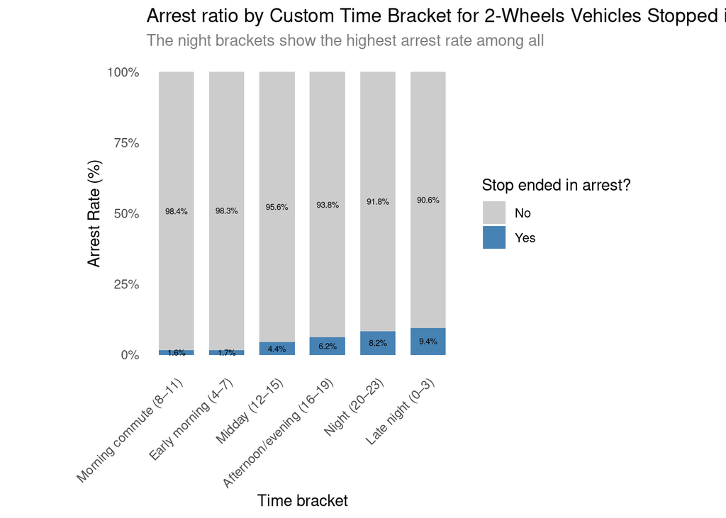

```r
vehstops %>%
  group_by(time_bracket, arrested) %>%
  summarise(count = n(), .groups = "drop_last") %>%
  mutate(percentage = count / sum(count))
```

```
## # A tibble: 12 × 4
## # Groups:   time_bracket [6]
##    time_bracket              arrested count percentage
##    <chr>                        <int> <int>      <dbl>
##  1 Afternoon/evening (16–19)        0 54415     0.938
##  2 Afternoon/evening (16–19)        1  3582     0.0618
##  3 Early morning (4–7)              0  6610     0.983
##  4 Early morning (4–7)              1   116     0.0172
##  5 Late night (0–3)                 0 12802     0.906
##  6 Late night (0–3)                 1  1328     0.0940
##  7 Midday (12–15)                   0 37027     0.956
##  8 Midday (12–15)                   1  1705     0.0440
##  9 Morning commute (8–11)           0 31102     0.984
## 10 Morning commute (8–11)           1   506     0.0160
## 11 Night (20–23)                    0 37026     0.918
## 12 Night (20–23)                    1  3323     0.0824
```

What can we say?